# Opgave 2 - Etik og BMI

### Overblik

AP pension praktiserer en politik, hvorved kunder kan risikerer afslag på at tegne livsforsikring, hvis der er tale om en kunde med forhøjet BMI på over 30. En person med et BMI på over 30 falder under kategorien “obese” og har derved større risiko for en række af helbredsproblemer og/eller tidlig død. Derfor mener AP pension, at der er for stor risiko ved at give en livsforsikring til denne kundegruppe. Med nedenstående 2 datasæt skal vi illustrere sammenhængen mellem forventede levealder og BMI for at understøtte deres forsikringspolitik.

1. *WHO-data* = Tal for forventede levetid og andel af “obese” personer i 178 lande
2. *Peru, Mexico, Colombia undersøgelse* = Spørgeskemaundersøgelse af 2111 respondenters livsstil

### Dataintroduktion og Fejlkilder

Før vi går i gang bliver vi nødt til at foreligge eventuel fejl og mangler ved begge datasæt samt. redegøre for datasættets variabler og andre nødvendige informationer.

##### WHO

I nedenstående vises der et udsnit af WHO-datasættet. Vi har ekskluderet enkelte variabler, så vi isoleret set kigger på fedme af begge køn. Kønsopdelt statisik af personer i den overvægtige og “obese” kategori er derfor fravalgt.

|  | Country | Year | Age | AllOB | LifeExpectancy |
| --- | --- | --- | --- | --- | --- |
| 1 | Afghanistan | 2018 | 18-69 | 17.0 | 63.081 |
| 2 | Albania | 2017 | 15-59 | 21.3 | 79.047 |
| 3 | Algeria | 2016 | 18-69 | 21.8 | 75.732 |
| 4 | American Samoa | 2017 | 18+ | 80.2 | NA |
| 5 | Andorra | 2017 | 18-75 | 13.6 | NA |
| 6 | Angola | 2013 | 15-64 | 6.8 | 59.307 |

Forklaring af variabler:

- *AllOB* (All obese): Procentdel af voksne over 18, hvis BMI er 30 kg/m² eller højere.
- *LifeExpectancy* (Forventede levealder): En mere kompleks beregning, som kan variere fra land til land. I Danmark udregnes forventede levealder kontinuerligt med variabler såsom: køn, kommune, alder osv.

Fejlkilder:

- Årstal varierer fra land til land. Det resulterer i, at tallene ikke er direkte sammenlignelige, da forventede levetid kan have ændret sig markant over tid. Ydermere er der enkelte lande, hvor tidsperioden strækker sig over flere årstal (eks. 2012-2014), her har vi taget udgangspunkt i det første årstal i perioden.
- 35 lande har NA værdier i *AllOB* eller *LifeExpectancy* og derfor udgår fra analysen

##### Peru, Mexico, Colombia undersøgelse

Nedenstående data er fra en spørgeskemaundersøgelse med respondenter fra Peru, Mexico og Colombia. Læs mere her: https://www.sciencedirect.com/science/article/pii/S2352340919306985?via%3Dihub

|  | Gender | Age | Height | Weight | family_history_with_overweight | FAVC | FCVC | NCP | CAEC | SMOKE | CH2O | SCC | FAF | TUE | CALC | MTRANS | NObeyesdad |
| --- | --- | --- | --- | --- | --- | --- | --- | --- | --- | --- | --- | --- | --- | --- | --- | --- | --- |
| 1 | Female | 21 | 1.62 | 64.0 | yes | no | 2 | 3 | Sometimes | no | 2 | no | 0 | 1 | no | Public_Transportation | Normal_Weight |
| 2 | Female | 21 | 1.52 | 56.0 | yes | no | 3 | 3 | Sometimes | yes | 3 | yes | 3 | 0 | Sometimes | Public_Transportation | Normal_Weight |
| 3 | Male | 23 | 1.80 | 77.0 | yes | no | 2 | 3 | Sometimes | no | 2 | no | 2 | 1 | Frequently | Public_Transportation | Normal_Weight |
| 4 | Male | 27 | 1.80 | 87.0 | no | no | 3 | 3 | Sometimes | no | 2 | no | 2 | 0 | Frequently | Walking | Overweight_Level_I |
| 5 | Male | 22 | 1.78 | 89.8 | no | no | 2 | 1 | Sometimes | no | 2 | no | 0 | 0 | Sometimes | Public_Transportation | Overweight_Level_II |
| 6 | Male | 29 | 1.62 | 53.0 | no | yes | 2 | 3 | Sometimes | no | 2 | no | 0 | 0 | Sometimes | Automobile | Normal_Weight |

Forklaring af variabler:

- *NObesity* (Obesity level):
  - Insufficient Weight = under 18.5
  - Normal Weight = 18.5 - 24.9
  - Overweight Level I = 25 - 29.9
  - Overweight Level II = Dokumentationen viser ikke en kategori 2 - vi antager at det også er 25 - 29.9
  - Obesity Type I = 30 - 34.9
  - Obesity Type II = 35 - 39.9
  - Obesity Type III = 40 +
- *FCVC*: Frequency of consumption of vegetables
- *NCP*: Number of main meals
- *CAEC*: Consumption of food between meals
- *CH20*: Consumption of water daily
- *CALC*: Consumption of alcohol
- *SCC*: Calories consumption monitoring
- *FAF*: Physical activity frequency
- *TUE*: Time using technology devices
- *MTRANS*: Transportation used

Fejlkilder:

Dette datasæt kigger på livsstil af respondenter i lande som Peru, Mexico og Colmbia. Vi har dog til opgave at finde andre variabler, som kan forklare forventede levetid. Men dette datasæt indeholder IKKE information om respondenternes levetid, og derfor er det en svær, hvis ikke umulig opgave, at finde andre variabler, som kan sige noget om forventede levetid ud fra livsstilsvariabler i dette datasæt. Derfor vælger vi ikke at gå videre med dette data. Dog kommer vi senere hen i opgaven med anbefaliner til, hvilke allerede eksisterende levetidsmodeler og variabler, som kunne være relevante at kigge på.

# Opgave 2.1

### Hvordan finder vi lande, som ligner DK i WHO-datasættet?

Vi har 178 lande i datasættet fra WHO. Det er en blanding af mange lande, som nødvendigvis ikke ligner Danmark. Hvis vi blot ser på sammenhængen mellem *Obesity* og *LifeExpectancy* for alle lande, så er der en positiv korrelation mellem de to variabler - altså et BMI over 30 har en positiv effekt på den forventede levealder. Det virker en smule underligt, hvis fedme skulle gå hen og have en positiv indvirkning på levetid….

```r
# Simpel lineær regression + korrelation
model1 <- lm(WHO_data_renset$LifeExpectancy ~ WHO_data_renset$AllOB)
korrelation1 <- cor(WHO_data_renset$AllOB, WHO_data_renset$LifeExpectancy, use="complete.obs")
r_square1 <- summary(model1)$r.squared
```

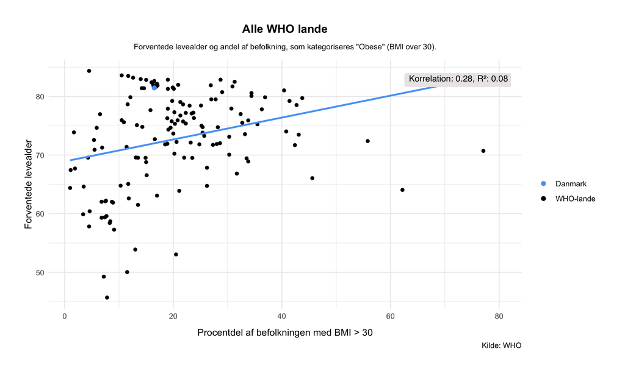

1. Se på Eurpæriske lande
2. Lande som ligner DK, hvad angår fedme og levealder (clustering)

Vi anvender begge metoder.

#### Europærisk opdeling

```r
WHO_Europa <- WHO_data_renset %>%
  filter(Country %in% c("Albania", "Andorra", "Armenia", "Austria", "Azerbaijan", "Belarus", "Belgium", "Bosnia and Herzegovina", "Bulgaria", "Croatia", "Cyprus", "Czechia", "Denmark", "Estonia", "Finland", "France", "Georgia", "Germany", "Greece", "Hungary", "Iceland", "Ireland", "Italy", "Latvia", "Liechtenstein", "Lithuania", "Luxembourg", "Malta", "Moldova", "Monaco", "Montenegro", "Netherlands", "North Macedonia", "Norway", "Poland", "Portugal", "Romania", "Russia", "San Marino", "Serbia", "Slovakia", "Slovenia", "Spain", "Sweden", "Switzerland", "Turkey", "Ukraine", "United Kingdom", "Vatican City"))
```

#### Clustering-opdeling

Vi anvender sihuette og elbow metoden til at finde antal clustre, som vi skal bruge:

```r
# klargør data
WHO_udenNA <- na.omit(WHO_data_renset)
data_standardized <- scale(WHO_udenNA[, c("LifeExpectancy", "AllOB")])

### SILHUETTE metoden

# funktion til at beregne silhuette metoden
silhouette_bredde <- function(k) {
  model <- kmeans(data_standardized, centers = 10) #clustering
  ss <- silhouette(model$cluster, dist(data_standardized)) #silhuettekoefficienten
  mean(ss[, 'sil_width']) #gennemsnit af silhuettekoefficienten
}

gnm_dist_10_klynger <- sapply(2:10, silhouette_bredde) #kør ovenstående function på 2 til 10 klynger
```

- Gennemsnittet af afstanden fra datapunktet til de andre punkter i samme klynge.
- Den mindste gennemsnitsafstand fra datapunktet til punkter i en anden klynge.

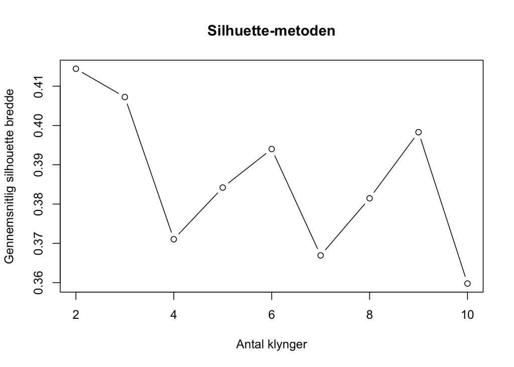

Vi ser også nærmere på Elbow-metoden, som viser det punkt, hvor forøgelsen af antal klynger ikke længere giver en signifikant forbedring af WSS. WSS skal være lav, da det er summen af de kvadrede afstande for alle datapunkter i en klynge. Hvis dette tal er lavt, så vil afstanden fra hvert datapunkt og tilhørende centroid generelt være lavt.

```r
### ELBOW metoden
wss <- numeric(10) # maksimalt antal klynger på 10
for (k in 1:10) {
  model <- kmeans(data_standardized, centers = k) # clustering
  wss[k] <- model$tot.withinss # summen af kvadrede afstande mellem hvert punkt og tilhørende centroid
}
```

Det ser ud til at det optimale antal klynger ligge omtrent 2-3.

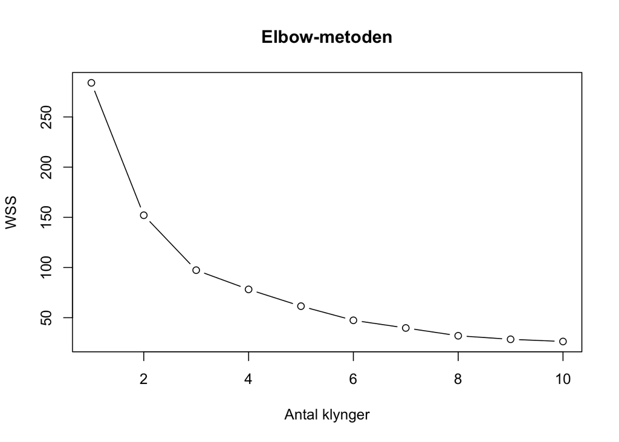

Vi vælger at opdele datasættet i 2 klynger. Ud fra nedenstående plot ser vi tydeligt, at der forekommer en opdeling af lande, som har en relativ høj levealder, men til gengæld også en større procentdel af befolkningen, som har et BMI over 30. Når vi dykker ned i, hvilke lande klyngerne består af, så tegner der sig også en rød tråd.

```r
### CLUSTERING MED 2 KLYNGER

# k-means
kmeans_resultat <- kmeans(data_standardized, centers = 2)

# tilføj klynger til datasæt
WHO_udenNA$Cluster <- kmeans_resultat$cluster

# gem dataframe med lande kun fra klynge 2
WHO_clustering <- WHO_udenNA %>%
  filter(Cluster %in% 1)
```

[figure not shown]

### Clustering opdeling vs. Europærisk opdeling

Vi ser nu på korrelationen mellem fedme og levetid samt. fedme som forklarende variabel for levetid i de nye opdelinger af datasættet.

```r
# KORRELATIONN OG SIMPEL LINEÆR REGRESSION

# Europa
model2 <- lm(WHO_Europa$LifeExpectancy ~ WHO_Europa$AllOB)
korrelation2 <- cor(WHO_Europa$AllOB, WHO_Europa$LifeExpectancy, use="complete.obs")
r_square2 <- summary(model2)$r.squared

# clustering-opdeling
model3 <- lm(WHO_clustering$LifeExpectancy ~ WHO_clustering$AllOB)
korrelation3 <- cor(WHO_clustering$AllOB, WHO_clustering$LifeExpectancy, use="complete.obs")
r_square3 <- summary(model3)$r.squared
```

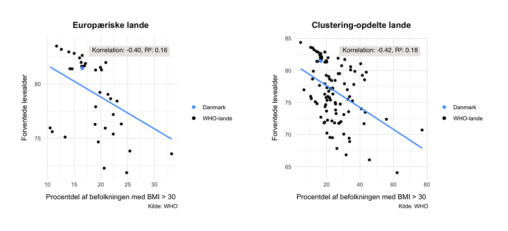

Nu ser vi en negativ korrelation mellem de 2 variabler. Fedme i disse lande har altså en negativ effekt for den forventede levealder. Selvom forklaringsgraden stadig er relativt lavt, så forklarer fedme nu henholdsvis 16% og 18%, som er en del mere end, hvis vi inddrager alle datasættets lande i analysen.

# Opgave 2.2

Vi vil nu gennemgå Mona Ebdrup sagen: [https://www.dr.dk/nyheder/penge/monas-bmi-er-hoejt-overvaegtige-naegtes-en-livsforsikring] og gøre os etiske overvejelser om AP Pensions politik om brugen af BMI i godkendelsesprocessen af livsforsikring.

## Hvad siger etikken?

### AP Pension bidrager til det fælles bedste (dydsetik)

Med dysetik in mente skal AP Pension handle *dydigt*. Det vil sige, at virksomheden hverken skal være lempelig eller streng i deres politik. Lempelig vil i dette tilfælde være, at tilbyde alle en forsikring - også dem med mange helbredproblemer. Streng vil på den anden side være kun at tilbyde den sundeste del af befolkning en forsikring (ikke ryger, ingen alkohol osv.) Vi skal stræbe efter en *golden mean*, som er alsidig og ansvarlig. I dette tilfælde vil det IKKE være ansvarligt at tilbyde livsforsikring til den del af befolkningen, som ikke er moderate i deres livsstil. Det vil ikke fremme kollektivets interesser om et sundt velfærd. Ydermere udviser AP Pension visdom ved at bruge statistik, som beviser at et forhøjet BMI kan være risiko for tidlig død. Det ville være både risikabelt og uintelligent ikke at tage statistikken med i overvejelserne.

### Er det universalbart at nægte personer med BMI over 37 en livsforsirking? (Kant)

Hvis alle forsikringsselskaber handlede på samme måde, ville det så være et samfund vi ønsker at leve i? Det kan augmenteres at det ikke er korrekt at systematisk udelukke personer grundet deres BMI. Det kan ligeledes være personer, som blot er meget trænet eller har andre lidelser, som medfører et forhøjet BMI. Det vil ikke være korrekt at udelukke denne del af befolkningen fra en basal ydelse, som en livsforsikring er. Det er derfor hverken universalbart eller retfærdigt.

### AP Pension har et ansvar overfor andre medlemmer (konsekvensetik)

At tilbyde personer med svær overvægt en livsforsikring kan medføre økonomiske konsekvenser for selskabet. I følge AP Pension er det nemlig ikke muligt blot at øge omkostningerne for livsforsikringen af det enkelte individ med en BMI over 37, da det simpelthen bliver for dyrt. Så hvis selskabet skal godkende disse personer, så vil omkostningerne generelt stige i selskabet. Selskabet påtager sig derved en øget risiko og kan være nødsaget til at lave pristigninger for alle medlemmer. Størstedelen af befolkningen er ikke svært overvægtige, og derfor vil det ikke have størst nytte for samfundet af inddrage svært overvægtige personer.

### Den langsigtede effekt af dårlig omtale (konsekvensetik)

Hvis vi dog ser på de langsigtede effekter af negativ omtale i pressen, så kan det også skade AP Pension. En negativ social opfattelse kan medføre tab af kunder, som i sidste ende ikke vil gavne selskabets økonomiske situation.

## KONKLUSION - Andre variabler?

Der er mange argumenter for at AP Pension ikke skal normalisere fedme, da det har en negativ effekt på samfundet. Dog er BMI som indikator ikke en tiltrækkelig variabel til at vurdere et individs forventede levetid. AP Pension kan ved så snævert et grundlag risikere at diskriminere individer, som i virkeligheden lever et sundt liv. Men, hvilke variabler skal vi så kigge på? I det udleverede datasæt om livsstil fra Colombia, Peru og Mexico kan vi ikke konkludere på andre variabler, som AP Pension retmæssigt kan bruge. Datasættet indeholder nemlig en masse variabler, som kan forklare om en person indgår i kategorien Obese eller ikke Obese… men det siger jo så ikke noget om levetid, og giver os ikke andre variabler som vil være interresant for os.

Dog kan AP Pension hente inspiration fra andre levetidsmodeler som indrager mere end kun BMI. Her kan man se på Alder, Køn, BMI, Søvnrytmer, miljø (luft og vandkvalitet ud fra kommune), motion og meget mere. Ved at se på flere variabler giver det et bedre helhedsbillede af nye kunder og forhindre også en potentiel “shit-storm”.

kilde: https://via.ritzau.dk/pressemeddelelse/13711656/atp:-danskernes-levetid-falder-for-andet-ar-i-traek?publisherId=12772933&lang=da

kilde: https://apps.goldensoncenter.uconn.edu/HLEC/